# Part I - Ford GoBike System Data Exploration

## Introduction

> This data set includes information about individual rides made in a bike-sharing system covering the greater San Francisco Bay Area.

## Preliminary Wrangling

```python
# import all packages and set plots to be embedded inline
import matplotlib.pyplot as plt
import numpy as np
import pandas as pd
import seaborn as sb

%matplotlib inline
```

```python
bike_trips = pd.read_csv('201902-fordgobike-tripdata.csv')
display(bike_trips.shape)
bike_trips.head()
```

```
(183412, 16)
```

|  | duration_sec | start_time | end_time | start_station_id | start_station_name | start_station_latitude | start_station_longitude | end_station_id | end_station_name | end_station_latitude | end_station_longitude | bike_id | user_type | member_birth_year | member_gender | bike_share_for_all_trip |
| --- | --- | --- | --- | --- | --- | --- | --- | --- | --- | --- | --- | --- | --- | --- | --- | --- |
| 0 | 52185 | 2019-02-28 17:32:10.1450 | 2019-03-01 08:01:55.9750 | 21.0 | Montgomery St BART Station (Market St at 2nd St) | 37.789625 | -122.400811 | 13.0 | Commercial St at Montgomery St | 37.794231 | -122.402923 | 4902 | Customer | 1984.0 | Male | No |
| 1 | 42521 | 2019-02-28 18:53:21.7890 | 2019-03-01 06:42:03.0560 | 23.0 | The Embarcadero at Steuart St | 37.791464 | -122.391034 | 81.0 | Berry St at 4th St | 37.775880 | -122.393170 | 2535 | Customer | NaN | NaN | No |
| 2 | 61854 | 2019-02-28 12:13:13.2180 | 2019-03-01 05:24:08.1460 | 86.0 | Market St at Dolores St | 37.769305 | -122.426826 | 3.0 | Powell St BART Station (Market St at 4th St) | 37.786375 | -122.404904 | 5905 | Customer | 1972.0 | Male | No |
| 3 | 36490 | 2019-02-28 17:54:26.0100 | 2019-03-01 04:02:36.8420 | 375.0 | Grove St at Masonic Ave | 37.774836 | -122.446546 | 70.0 | Central Ave at Fell St | 37.773311 | -122.444293 | 6638 | Subscriber | 1989.0 | Other | No |
| 4 | 1585 | 2019-02-28 23:54:18.5490 | 2019-03-01 00:20:44.0740 | 7.0 | Frank H Ogawa Plaza | 37.804562 | -122.271738 | 222.0 | 10th Ave at E 15th St | 37.792714 | -122.248780 | 4898 | Subscriber | 1974.0 | Male | Yes |

```python
bike_trips.info()
```

```
<class 'pandas.core.frame.DataFrame'>
RangeIndex: 183412 entries, 0 to 183411
Data columns (total 16 columns):
 #   Column                   Non-Null Count   Dtype
---  ------                   --------------   -----
 0   duration_sec             183412 non-null  int64
 1   start_time               183412 non-null  object
 2   end_time                 183412 non-null  object
 3   start_station_id         183215 non-null  float64
 4   start_station_name       183215 non-null  object
 5   start_station_latitude   183412 non-null  float64
 6   start_station_longitude  183412 non-null  float64
 7   end_station_id           183215 non-null  float64
 8   end_station_name         183215 non-null  object
 9   end_station_latitude     183412 non-null  float64
 10  end_station_longitude    183412 non-null  float64
 11  bike_id                  183412 non-null  int64
 12  user_type                183412 non-null  object
 13  member_birth_year        175147 non-null  float64
 14  member_gender            175147 non-null  object
 15  bike_share_for_all_trip  183412 non-null  object
dtypes: float64(7), int64(2), object(7)
memory usage: 22.4+ MB
```

```python
bike_trips.isna().sum()
```

```
duration_sec                  0
start_time                    0
end_time                      0
start_station_id            197
start_station_name          197
start_station_latitude        0
start_station_longitude       0
end_station_id              197
end_station_name            197
end_station_latitude          0
end_station_longitude         0
bike_id                       0
user_type                     0
member_birth_year          8265
member_gender              8265
bike_share_for_all_trip       0
dtype: int64
```

there is a lot of Nan values in `membre_birth_year` and `member_gender`, i think i'll drop them when i do some exploration in those variables.

```python
# convert user_type, member_gender, and bike_share_for_all_trip into categorical types.
to_convert = ['user_type', 'member_gender', 'bike_share_for_all_trip']
for column in to_convert:
    bike_trips[column] = bike_trips[column].astype('category')
```

```python
# convert start_time and end_time to datetime type.
bike_trips.start_time = pd.to_datetime(bike_trips.start_time)
bike_trips.end_time = pd.to_datetime(bike_trips.end_time)
```

```python
# let's see how many stations are there
bike_trips.start_station_id.nunique()
```

```
329
```

```python
bike_trips.describe()
```

|  | duration_sec | start_station_id | start_station_latitude | start_station_longitude | end_station_id | end_station_latitude | end_station_longitude | bike_id | member_birth_year |
| --- | --- | --- | --- | --- | --- | --- | --- | --- | --- |
| count | 183412.000000 | 183215.000000 | 183412.000000 | 183412.000000 | 183215.000000 | 183412.000000 | 183412.000000 | 183412.000000 | 175147.000000 |
| mean | 726.078435 | 138.590427 | 37.771223 | -122.352664 | 136.249123 | 37.771427 | -122.352250 | 4472.906375 | 1984.806437 |
| std | 1794.389780 | 111.778864 | 0.099581 | 0.117097 | 111.515131 | 0.099490 | 0.116673 | 1664.383394 | 10.116689 |
| min | 61.000000 | 3.000000 | 37.317298 | -122.453704 | 3.000000 | 37.317298 | -122.453704 | 11.000000 | 1878.000000 |
| 25% | 325.000000 | 47.000000 | 37.770083 | -122.412408 | 44.000000 | 37.770407 | -122.411726 | 3777.000000 | 1980.000000 |
| 50% | 514.000000 | 104.000000 | 37.780760 | -122.398285 | 100.000000 | 37.781010 | -122.398279 | 4958.000000 | 1987.000000 |
| 75% | 796.000000 | 239.000000 | 37.797280 | -122.286533 | 235.000000 | 37.797320 | -122.288045 | 5502.000000 | 1992.000000 |
| max | 85444.000000 | 398.000000 | 37.880222 | -121.874119 | 398.000000 | 37.880222 | -121.874119 | 6645.000000 | 2001.000000 |

### What is the structure of your dataset?

> There are 183,412 trips in the dataset with 16 features:

bike_id bike_share_for_all_trip duration_sec end_station_id end_station_latitude end_station_longitude end_station_name end_time member_birth_year member_gender start_station_id start_station_latitude start_station_longitude start_station_name start_time user_type The dataset contain 2 datetime variables (start_time, end_time), 3 categorical variables (user_type, member_gender, bike_share_for_all_trip) and a variable that contain stations names (start_station_name, end_station_name) which there is 329 station and the rest of variable are numerical.

### What is/are the main feature(s) of interest in your dataset?

> I'm interested in different patterns and characteristics of trips like duration or trips taken in terms of time of day, day of the week, or month of the year with its variation by user type and gender.

### What features in the dataset do you think will help support your investigation into your feature(s) of interest?

> i'll use all the columns in the dataset except the latitude and longitude columns.

let's first drop the columns that i don't need in my analysis.

```python
bike_trips.drop(
    columns=['start_station_latitude', 'end_station_latitude', 'start_station_longitude', 'end_station_longitude'],
    inplace=True)
bike_trips.head()
```

|  | duration_sec | start_time | end_time | start_station_id | start_station_name | end_station_id | end_station_name | bike_id | user_type | member_birth_year | member_gender | bike_share_for_all_trip |
| --- | --- | --- | --- | --- | --- | --- | --- | --- | --- | --- | --- | --- |
| 0 | 52185 | 2019-02-28 17:32:10.145 | 2019-03-01 08:01:55.975 | 21.0 | Montgomery St BART Station (Market St at 2nd St) | 13.0 | Commercial St at Montgomery St | 4902 | Customer | 1984.0 | Male | No |
| 1 | 42521 | 2019-02-28 18:53:21.789 | 2019-03-01 06:42:03.056 | 23.0 | The Embarcadero at Steuart St | 81.0 | Berry St at 4th St | 2535 | Customer | NaN | NaN | No |
| 2 | 61854 | 2019-02-28 12:13:13.218 | 2019-03-01 05:24:08.146 | 86.0 | Market St at Dolores St | 3.0 | Powell St BART Station (Market St at 4th St) | 5905 | Customer | 1972.0 | Male | No |
| 3 | 36490 | 2019-02-28 17:54:26.010 | 2019-03-01 04:02:36.842 | 375.0 | Grove St at Masonic Ave | 70.0 | Central Ave at Fell St | 6638 | Subscriber | 1989.0 | Other | No |
| 4 | 1585 | 2019-02-28 23:54:18.549 | 2019-03-01 00:20:44.074 | 7.0 | Frank H Ogawa Plaza | 222.0 | 10th Ave at E 15th St | 4898 | Subscriber | 1974.0 | Male | Yes |

## Univariate Exploration

I’ll start by looking at the distributions of different variables in the dataset.

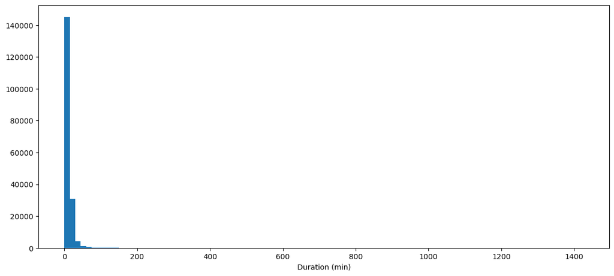

```python
# first I'll look at the distribution of duration variable.

# creating duration by minutes column
bike_trips['duration_min'] = np.round(bike_trips.duration_sec / 60.0)
# start with a standard-scaled plot
binsize = 15
bins = np.arange(0, bike_trips['duration_min'].max() + binsize, binsize)

# set plot dimensions
plt.figure(figsize=[14, 6])

plt.hist(data=bike_trips, x='duration_min', bins=bins)
plt.xlabel('Duration (min)')
plt.show()
```

it looks like there is outliers in the duration variable, i'll investigate more.

```python
# selecting durations that does not match (end_time - start_time)
real_durations = bike_trips.end_time - bike_trips.start_time
incorrect_durations = (real_durations.dt.seconds != bike_trips.duration_sec)
incorrect_durations.sum()
```

```
0
```

fair enough, no incorrect durations.

```python
bike_trips['duration_min'].describe()
```

```
count    183412.000000
mean         12.101340
std          29.908512
min           1.000000
25%           5.000000
50%           9.000000
75%          13.000000
max        1424.000000
Name: duration_min, dtype: float64
```

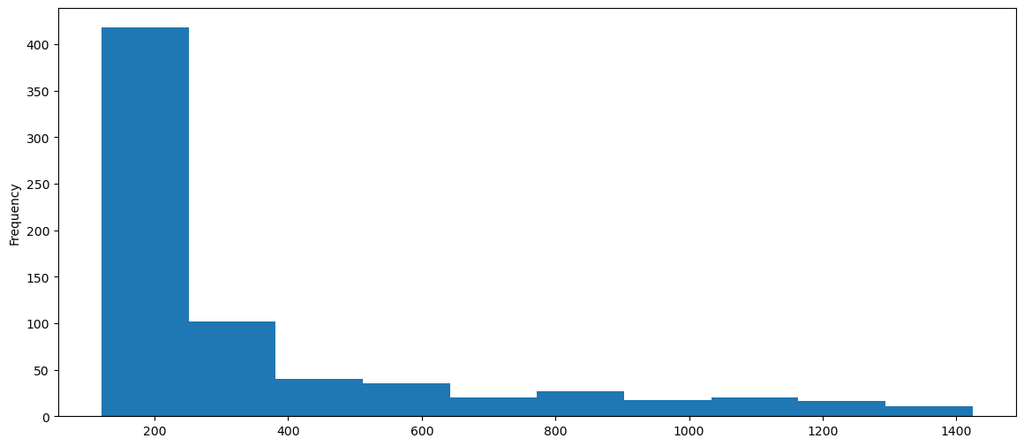

```python
# plotting the outliers
more_than_120_min = bike_trips.duration_min > 120
# set plot dimensions
plt.figure(figsize=[14, 6])

bike_trips.loc[more_than_120_min, 'duration_min'].plot(kind='hist');
```

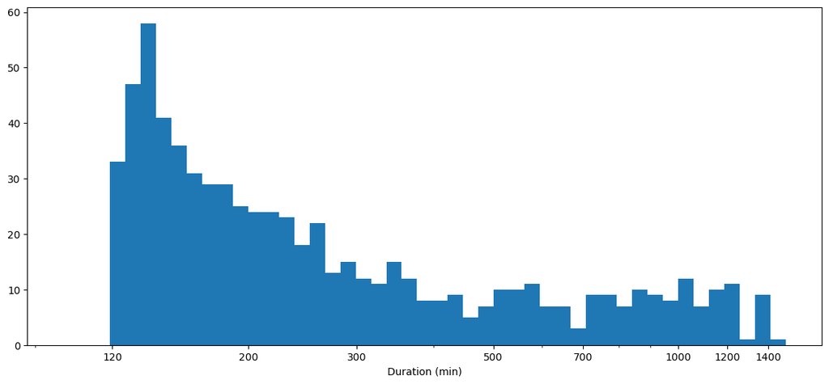

```python
# there's a long tail in the distribution, so let's put it on a log scale instead
outliers = bike_trips[more_than_120_min]

log_binsize = 0.025
bins = 10 ** np.arange(2.0, np.log10(outliers.duration_min.max())+log_binsize, log_binsize)

# set plot dimensions
plt.figure(figsize=[14, 6])

plt.hist(data =outliers, x ='duration_min', bins = bins)
plt.xscale('log')
plt.xticks([120, 200, 300, 500, 700, 1000, 1200, 1400], [120, 200, 300, 500, 700, 1000, 1200, 1400])
plt.xlabel('Duration (min)')
plt.show()
```

trips that have more than 120 min duration has a long tail distribution and even with the log scale there still diminishing quickly with the peak is around 130 minutes trips.

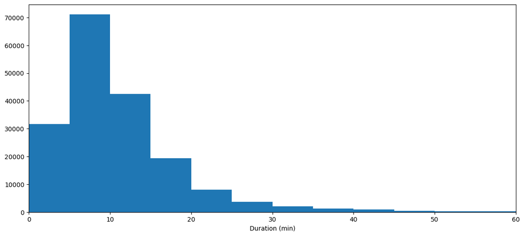

```python
# now coming back to normal values
binsize = 5
bins = np.arange(0, bike_trips['duration_min'].max() + binsize, binsize)

# set plot dimensions
plt.figure(figsize=[14, 6])

plt.hist(data=bike_trips, x='duration_min', bins=bins)
plt.xlabel('Duration (min)')
plt.xlim([0, 60])
plt.show()
```

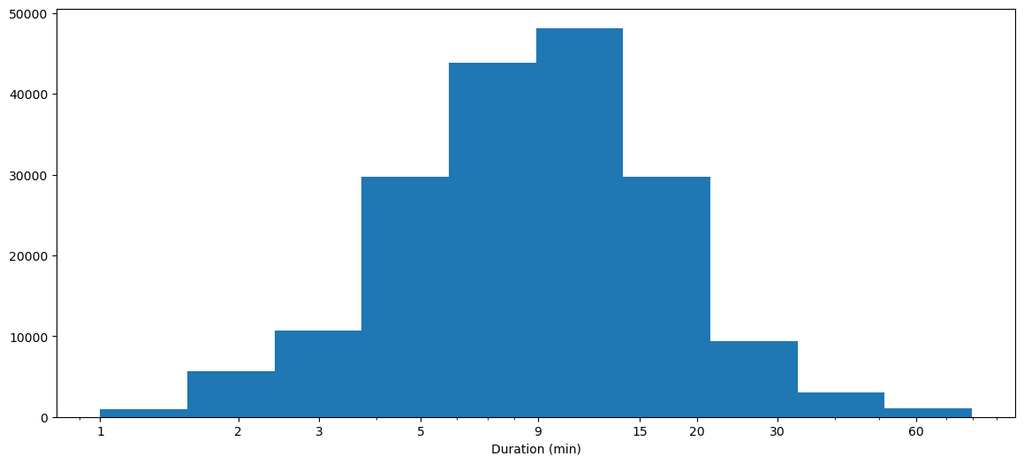

```python
log_binsize = 0.19
bins = 10 ** np.arange(0.0, np.log10(60)+log_binsize, log_binsize)

# set plot dimensions
plt.figure(figsize=[14, 6])

plt.hist(data =bike_trips, x ='duration_min', bins = bins)
plt.xscale('log')
plt.xticks([1, 2, 3, 5, 9, 15, 20, 30, 60,], [1, 2, 3, 5, 9, 15, 20, 30, 60,])

plt.xlabel('Duration (min)')
plt.show()
```

when plotted in log-scale the duration variable looks uni-model with a peak between 9 and 15 minutes.

```python
def my_count_plot(df, x, hue_var=None, color=0, palette=None, order=None, figsize=(14, 6)):
    """a quick hack to make count plot """
    if figsize:
        plt.figure(figsize=figsize)

    sb.countplot(data=df, x=x, hue=hue_var, color=sb.color_palette()[color], palette=palette, order=order, edgecolor='black')
    x = x.replace('_', " ")
    if hue_var:
        hue_var = hue_var.replace('_', " ")

    plt.title(f'''Distribution of {x} {'by' if hue_var else ''}'''.title(), fontsize=14, weight="bold")
    plt.xlabel(x.title(), fontsize=10, weight="bold")
    plt.ylabel('Frequency'.title(), fontsize=10, weight="bold");
```

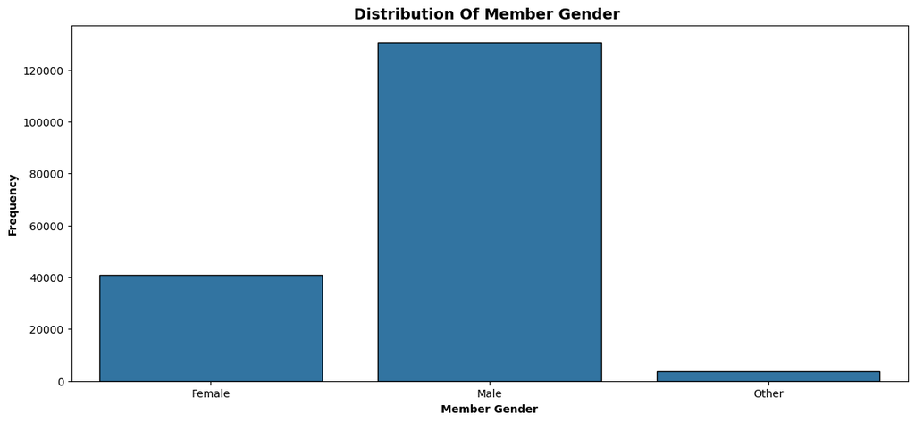

```python
# now I'll see the distribution of members by gender
my_count_plot(bike_trips, "member_gender")
```

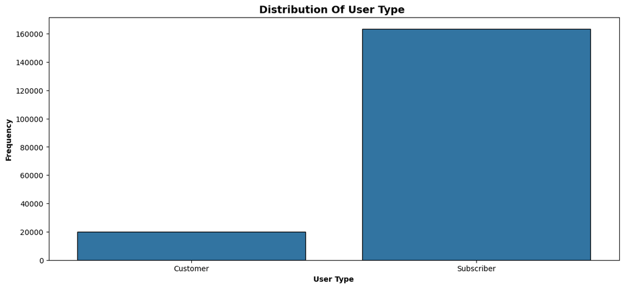

```python
# plotting user_type distribution
my_count_plot(bike_trips, 'user_type')
```

so most users are actually subscribers, that's not surprising.

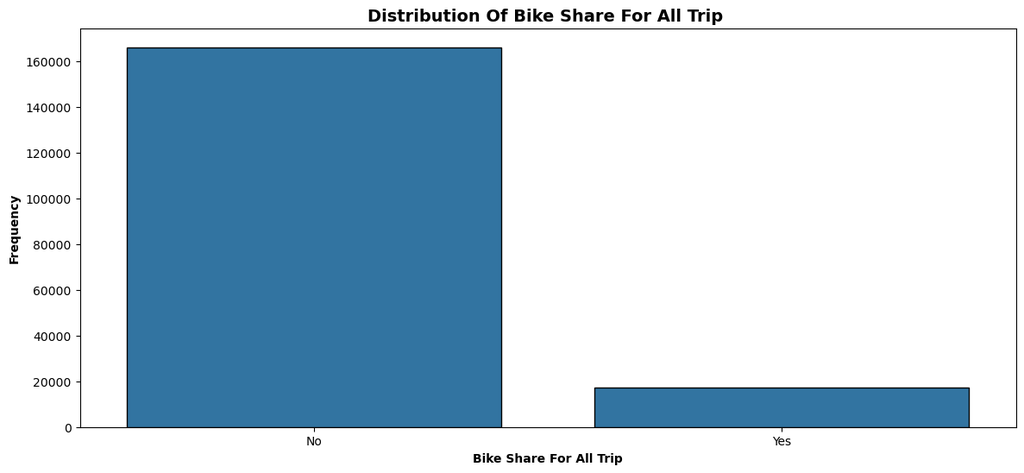

```python
# next I'll investigate the proportion of trips are by members who are enrolled in the "Bike Share for All"
# program for low-income residents
my_count_plot(bike_trips, 'bike_share_for_all_trip')
```

more than 90% of members are not enrolled in the "Bike Share for All" program.

I'll turn next to the distribution of members ages.

```python
bike_trips.member_birth_year.value_counts()
```

```
1988.0    10236
1993.0     9325
1989.0     8972
1990.0     8658
1991.0     8498
          ...
1928.0        1
1878.0        1
1930.0        1
1910.0        1
1927.0        1
Name: member_birth_year, Length: 75, dtype: int64
```

```python
# extracting the year of end_time
end_time_year = bike_trips.end_time.dt.year
bike_trips['member_age'] = (end_time_year - bike_trips.member_birth_year).astype('Int32')
bike_trips.member_age.value_counts()
```

```
31     10236
26      9325
30      8972
29      8658
28      8498
       ...
91         1
141        1
89         1
109        1
92         1
Name: member_age, Length: 75, dtype: Int64
```

look's like we have someone with age 141 who used a bike ones, I suspect that to be not true but i can't be sure.

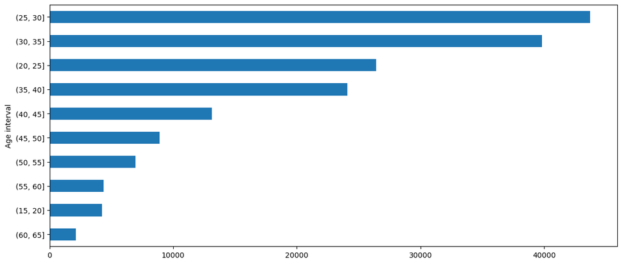

```python
# dividing ages into intervals and plotting the top 10 frequencies.
# set plot dimensions
plt.figure(figsize=[14, 6])

bin_edges = np.arange(15, bike_trips.member_age.max() + 5, 5)
pd.cut(bike_trips.member_age, bin_edges) \
    .value_counts(ascending=True) \
    .tail(10) \
    .plot(kind='barh')

plt.ylabel('Age interval');
```

most active age interval in this data set are the ones between 25 and 35.

investigating the most frequent station.

```python
def plot_top_frequencies(df, column, top=10):
    """a quick hack to plot top frequencies by a given column."""
    # set plot dimensions
    plt.figure(figsize=[14, 6])

    df[column] \
        .value_counts(ascending=True) \
        .tail(top) \
        .plot(kind='barh');
```

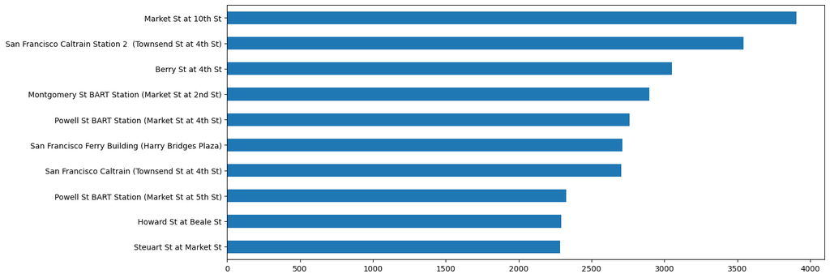

```python
# first the top 10 frequent start_stations
plot_top_frequencies(bike_trips, 'start_station_name')
```

so Market St is the most frequent start station.

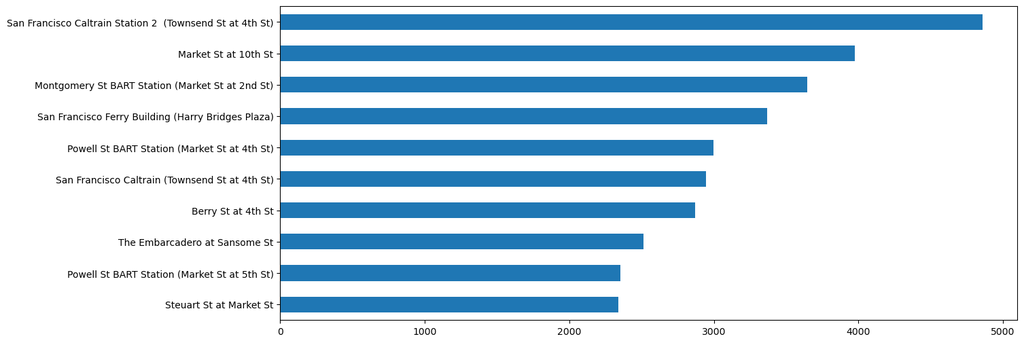

```python
# let's see the end_stations.
plot_top_frequencies(bike_trips, 'end_station_name')
```

the first one is San Fransisco Caltrain Station 2. I see that the first one in end stations is the second in start stations and vice versa.

let's see which one in most frequent overall.

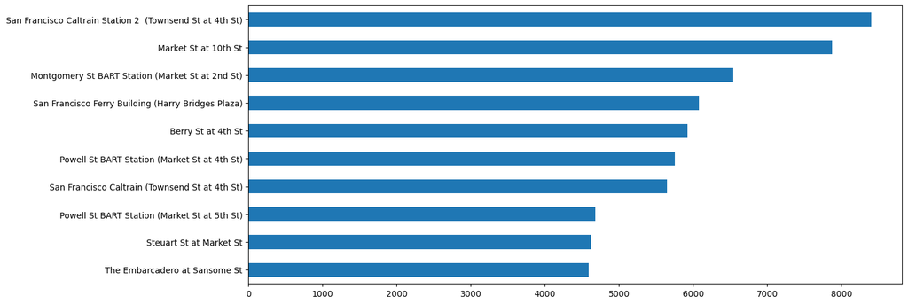

```python
stations = bike_trips.melt(value_vars=['start_station_name', 'end_station_name'],
                          var_name='station_role', value_name='station').dropna()
plot_top_frequencies(stations, 'station')
```

San Francisco Caltrain Station 2 is the most frequent station in this dataset.

### Discuss the distribution(s) of your variable(s) of interest. Were there any unusual points? Did you need to perform any transformations?

> - the trips durations have some outliers so after limiting the range the trips and applying log transform the data looked unimodal with a peak between 9 and 15 minutes.
> - most customers are males.
> - the overwhelming majority of users are subscribers.
> - most members have between 25 and 35 years old.
> - San Francisco Caltrain Station 2 is the most frequent station.

### Of the features you investigated, were there any unusual distributions? Did you perform any operations on the data to tidy, adjust, or change the form of the data? If so, why did you do this?

> the duration variable have a set of really long trips (eg 10 hours, 20 hours) i didn't remove them because they might be real values.

same thing apply to members ages there are very old people who used the bike.

## Bivariate Exploration

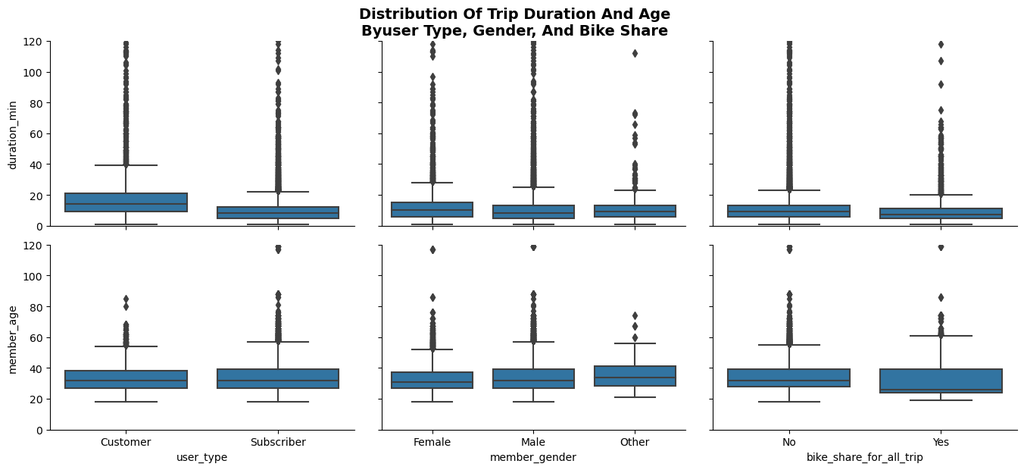

```python
# plot matrix of numeric features against categorical features.
# I'll use a smale sample from data so that it will not take too long.

samples = np.random.choice(bike_trips.index, 20000, replace = False)
bike_trips_samp = bike_trips.loc[samples]

def boxgrid(x, y, **kwargs):
    """ Quick hack for creating box plots with seaborn's PairGrid. """
    default_color = sb.color_palette()[0]
    sb.boxplot(x=x, y=y, color = default_color)
    plt.ylim([0, 120])


# retrieving categorical variables
categorical_vars = to_convert

# set plot dimensions
g = sb.PairGrid(data = bike_trips_samp,
                y_vars = ['duration_min', 'member_age'],
                x_vars = categorical_vars,
                aspect = 1.5)
g.map(boxgrid)

plt.suptitle('Distribution of trip duration and age\nbyUser Type, gender, and bike share'.title(), y=1.04, fontsize=14, weight='bold')

## Set Plot Dimensions - FIGURE LEVEL
g.fig.set_size_inches(14, 6)
plt.show();
```

there is not much difference between durations and ages across difference categorical variables after i adjusted for outliers, although i see that the trips durations of customers are more on average the subscribers let's zoom in and see by how much.

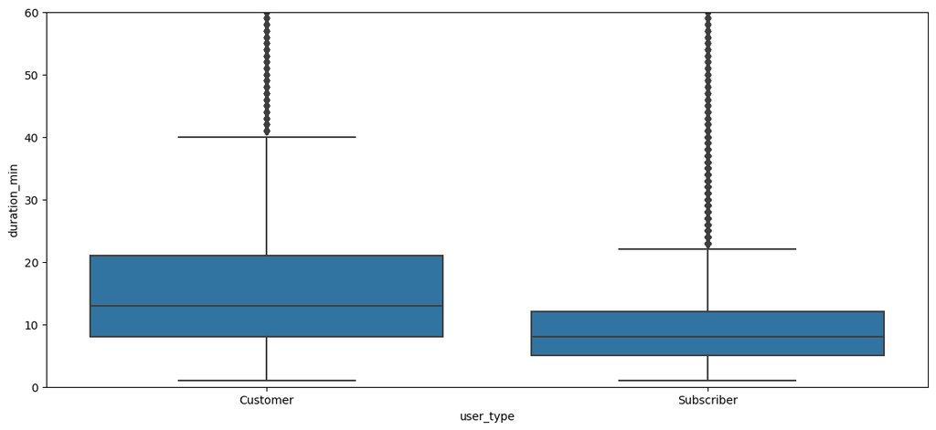

```python
# set plot dimensions
plt.figure(figsize=[14, 6])
default_color = sb.color_palette()[0]
sb.boxplot(data=bike_trips, x='user_type', y='duration_min', color=default_color)
plt.ylim([0, 60]);
```

yes, customers take longer trips than subscribers on average.

now I'll turn to time and see what I can find

```python
# getting rid of outliers
short_trips = bike_trips[-more_than_120_min]
# setting start time as index to begin time analysis
short_trips.set_index('start_time', inplace=True)
```

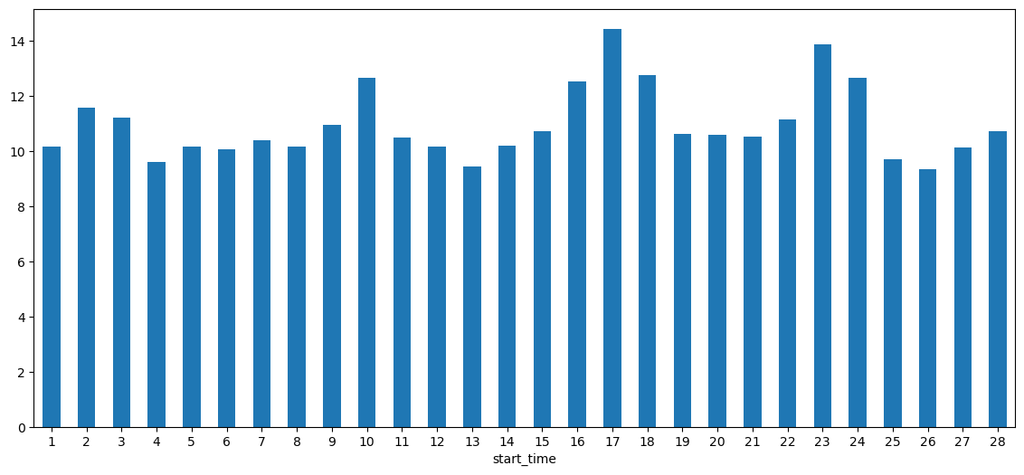

```python
# set plot dimensions
plt.figure(figsize=[14, 6])
# plotting by day of month
short_trips.resample('D')['duration_min'].mean().plot.bar()
plt.xticks(np.arange(28), np.arange(1, 29))
plt.xticks(rotation=0);
```

there is a lot of ups and downs. Maybe the ups are for the weekends, let's see.

```python
day_order = ['Monday', 'Tuesday', 'Wednesday', 'Thursday', 'Friday', 'Saturday', 'Sunday']
```

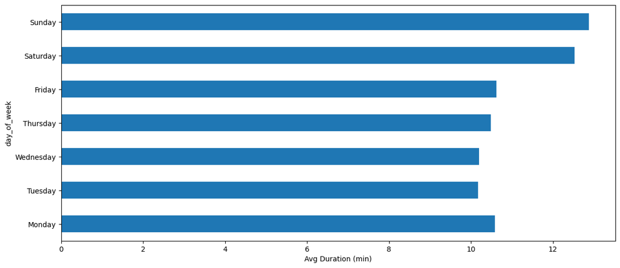

```python
# set plot dimensions
plt.figure(figsize=[14, 6])
short_trips = short_trips.assign(day_of_week = short_trips.index.day_name())
short_trips.groupby('day_of_week')\
    .duration_min.mean()\
    .reindex(day_order)\
    .plot.barh()
plt.xlabel('Avg Duration (min)');
```

as I expected the trips on weekends take longer than normal days trips.

What about hours of day ?

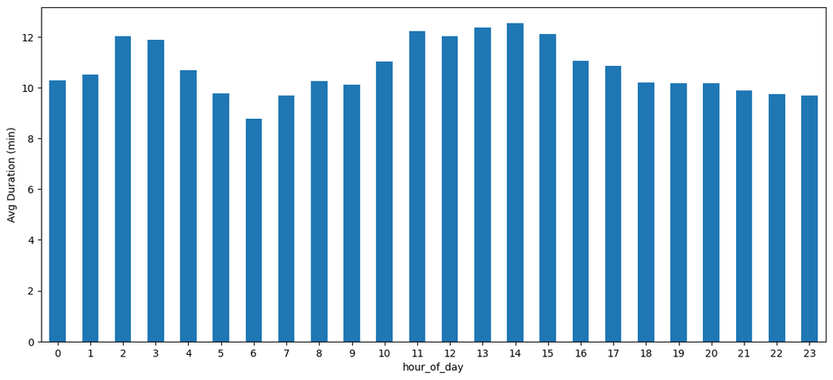

```python
# set plot dimensions
plt.figure(figsize=[14, 6])
short_trips = short_trips.assign(hour_of_day = short_trips.index.hour)
short_trips.groupby("hour_of_day")\
    .duration_min.mean()\
    .plot.bar()
plt.xticks(rotation=0)
plt.ylabel('Avg Duration (min)');
```

we have two peaks of duration on around 2 to 3 a.m and the other is between 11 a.m to 3 p.m.

let's see the average duration by gender.

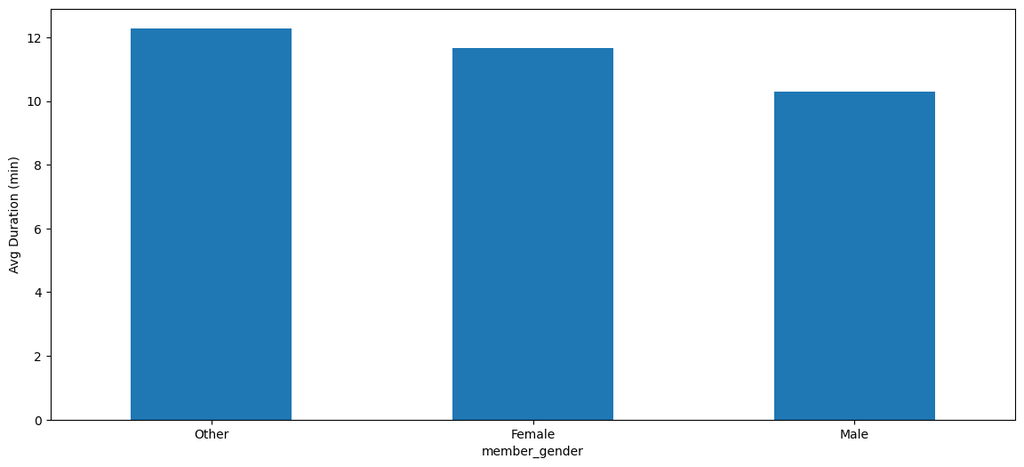

```python
# set plot dimensions
plt.figure(figsize=[14, 6])
short_trips.groupby('member_gender') \
    .duration_min.mean() \
    .sort_values(ascending=False) \
    .plot.bar()
plt.xticks(rotation=0)
plt.ylabel('Avg Duration (min)');
```

so we see here that the members are in `Other` category take on average longer trips followed by `Female` category. but there is a caveat: there is only 3622 members in `Other` category so the result may not be accurate enough.

let's plot average duration by age category

```python
# assigning each age to appropriate age interval.
bin_edges = np.arange(15, bike_trips.member_age.max() + 5, 5)
short_trips = short_trips.assign(age_interval = pd.cut(short_trips.member_age, bin_edges))
```

```python
short_trips.groupby('age_interval').size()
```

```
age_interval
(15, 20]       4231
(20, 25]      26345
(25, 30]      43555
(30, 35]      39720
(35, 40]      23990
(40, 45]      13078
(45, 50]       8880
(50, 55]       6947
(55, 60]       4346
(60, 65]       2148
(65, 70]        800
(70, 75]        310
(75, 80]         71
(80, 85]          5
(85, 90]        110
(90, 95]          2
(95, 100]         3
(100, 105]        0
(105, 110]        1
(110, 115]        0
(115, 120]       70
(120, 125]        0
(125, 130]        0
(130, 135]        0
(135, 140]        0
(140, 145]        1
dtype: int64
```

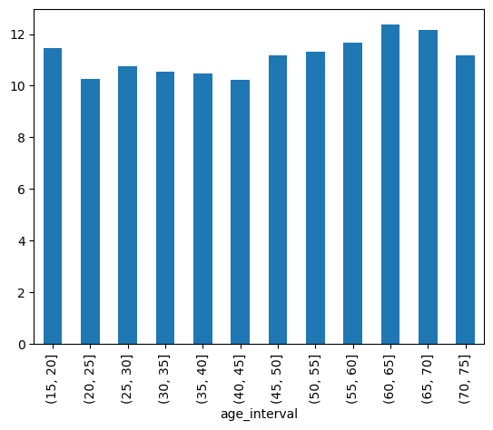

```python
# computing average duration by age interval
# and keeping only intervals that have enough samples so that the result of averaging is meaningful
short_trips.groupby('age_interval') \
    .duration_min.mean() \
    .head(12) \
    .plot.bar();
```

so the older, the more you tend to take longer trips, but i will not depend heavily on this result given that there is not too many members with older age.

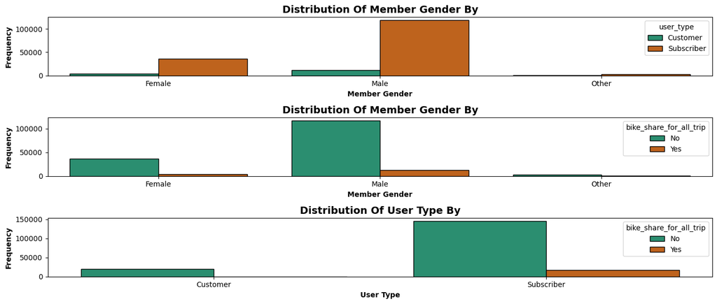

```python
# since there's only three subplots to create, using the full data should be fine.
# set plot dimensions
plt.figure(figsize=[14, 6])

to_plot = [['member_gender', 'user_type'], # subplot 1: member_gender vs user_type
           ['member_gender', 'bike_share_for_all_trip'], # subplot 2: member_gender vs. bike_share_for_all_trip
           ['user_type', 'bike_share_for_all_trip']] # subplot 3: user_type vs. bike_share_for_all_trip

for i in range(len(to_plot)):
    var1, var2 = to_plot[i]
    plt.subplot(3, 1, i+1)
    my_count_plot(bike_trips, var1, hue_var=var2, figsize=None, palette='Dark2')

plt.tight_layout();
```

the proportion of user_type and bike_share_for_all_trip seem to be similar across gender, and it seems that customers can't enroll in bike_share_for_all_trip program.

### Talk about some of the relationships you observed in this part of the investigation. How did the feature(s) of interest vary with other features in the dataset?

> - customers take longer trips than subscribers on average.
> - trips on weekends take longer than other days trips.
> - trips around 2 to 3 a.m and the between 11 a.m to 3 p.m take longer on average then trips on other times.
> - the members of `Other` category in `member_gender` take on average longer trips then `Female`'s and `Male`'s.

taking into account that only 3622 members are in `Other` category so the result may not be accurate enough.

> - members with different ages take the same average duration trips with a slight increase in older people.

### Did you observe any interesting relationships between the other features (not the main feature(s) of interest)?

> no, nothing worth mentioning.

## Multivariate Exploration

first let's see average duration across days of week by different categories.

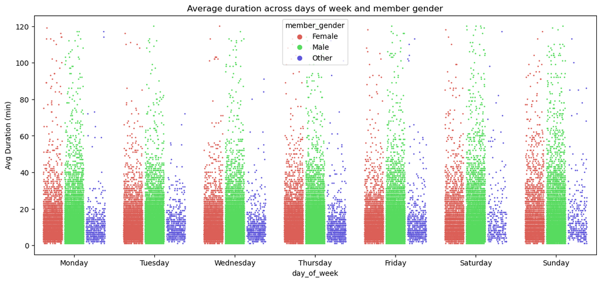

```python
# set plot dimensions
plt.figure(figsize=[14, 6])
ax = sb.stripplot(data=short_trips,
                  x='day_of_week',
                  y='duration_min',
                  hue='member_gender',
                  order=day_order,
                  palette='hls',
                  size=2, jitter=0.35, dodge=True)
plt.title('Average duration across days of week and member gender')
plt.ylabel('Avg Duration (min)')
ax.set_yticklabels([], minor=True)
plt.show();
```

no significant difference in average duration appear from this plot.

what about user_type ?

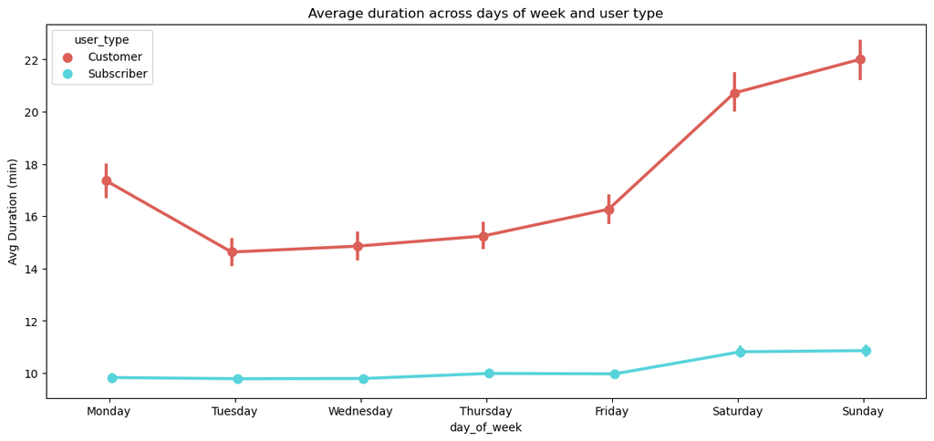

```python
# set plot dimensions
plt.figure(figsize=[14, 6])
ax = sb.pointplot(data = short_trips,
                  x = 'day_of_week',
                  y = 'duration_min',
                  hue = 'user_type',
                  order=day_order,
           palette = 'hls', linestyles = '-', dodge = True)
plt.title('Average duration across days of week and user type')
plt.ylabel('Avg Duration (min)')
ax.set_yticklabels([],minor = True)
plt.show();
```

the point plot shows a very steep increase in average duration for `Customer` in weekends in comparison to the increase for `Subscriber` members.

plotting for bike_share_for_all_trip

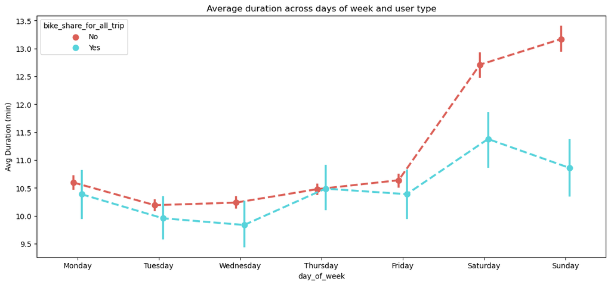

```python
# set plot dimensions
plt.figure(figsize=[14, 6])
ax = sb.pointplot(data = short_trips, x = 'day_of_week', y = 'duration_min', hue = 'bike_share_for_all_trip', order=day_order,
           palette = 'hls', linestyles = '--', dodge = 0.1)
plt.title('Average duration across days of week and user type')
plt.ylabel('Avg Duration (min)')
ax.set_yticklabels([],minor = True)
plt.show();
```

this plot show that there is a steep increase in average duration for members not enrolled in bike_share_for_all program while the increase for members enrolled in the program is not that steep.

### Talk about some of the relationships you observed in this part of the investigation. Were there features that strengthened each other in terms of looking at your feature(s) of interest?

> average duration for `Customer` in weekends increases vary rapidly in comparison to the increase for `Subscriber` members,

the same remark go for the members who are not enrolled in the bike_share_for_all_trip program and who are enrolled.

## Conclusions

my investigation of Ford GoBike System Data had lead me to the following conclusions:

> - the overwhelming majority of users are subscribers.
> - the average trip duration is between 9 and 15 minutes.
> - most customers are males.
> - most members have between 25 and 35 years old.
> - San Francisco Caltrain Station 2 is the most frequent station taking it into account as a start and as an end station.
> - customers take longer trips than subscribers on average.
> - trips on weekends take longer than weekdays trips.
> - trips around 2 to 3 a.m and the between 11 a.m to 3 p.m take longer on average then trips on other times.
> - members across ages take the same average duration trips with a slight increase in older people.
> - average duration for `Customer` in weekends increases vary rapidly in comparison to the increase for `Subscriber` members,

and that also apply for the members who are not enrolled in the bike_share_for_all_trip program in comparison to members who are enrolled.